# Practicum 1

John Keith

October 4 2023

## 1 / Predicting Breast Cancer

### 1.1 / Analysis of Data Distribution

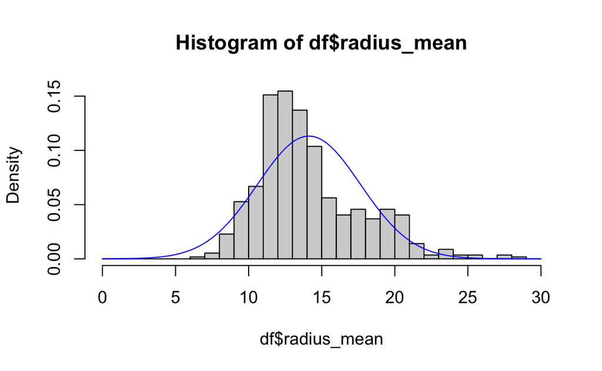

From the Shapiro-Wilk test, we find that the p-value from the test is 3.1056435^{-14}, which is much less than p = 0.05, therefore showing that the data is not normally distributed.

### 1.2 / Identification of Outliers

```r
find_outliers <- function(column){
  m <- mean(column)
  std_column <- sd(column)
  z_score <- abs(m - column[1:length(column)]) / std_column
  return(which(z_score > 2.5))
  }
num_outliers <- 0
for (i in 2:ncol(df)){
  outliers <- find_outliers(df[,i])
  print(paste('Outliers for column', colnames(df[i]), 'are in rows'))
  print(outliers)
  num_outliers <- num_outliers + length(outliers)

}
```

```
[1] "Outliers for column radius_mean are in rows"
 [1]  83 123 165 181 203 213 237 340 353 462 504 522
[1] "Outliers for column texture_mean are in rows"
[1] 220 233 240 260 266 456 563
[1] "Outliers for column perimeter_mean are in rows"
 [1]  83 109 123 181 203 213 237 340 353 462 522
[1] "Outliers for column area_mean are in rows"
 [1]  83 123 165 181 203 213 237 340 353 369 462 504 522
[1] "Outliers for column smoothness_mean are in rows"
[1]   4 106 109 123 204 258 505 521 569
[1] "Outliers for column compactness_mean are in rows"
 [1]   1   4  10  13  79  83 109 123 182 191 259 352 401 568
[1] "Outliers for column concavity_mean are in rows"
 [1]   1  69  79  83 109 113 123 153 203 213 259 352 353 401 462 564 568
[1] "Outliers for column concave.points_mean are in rows"
```

[output cut: 47 more lines]

The above code outputs all of the outliers per column. As you can see, there are a decent amount of outliers for each column, making it important to deal with/normalize. If I were performing a statistical/machine learning task that assumed a normal distribution (such as linear regression), I would simply standardize the data using the z-score method. Otherwise, I would probably use the min-max normalization method in order to get the entire column of data on a scale of 0 to 1, in order to allow the machine learning task to not get thrown off by a difference in scales. To find the outliers in each column, I used the z-score formula in combination wtih the which function to see which data points in a column were greater than 2.5. The amount of outliers I found were 388.

### 1.3 / Data Preparation

```r
for (i in 2:ncol(df)){
  df[,i] <- (df[,i] - mean(df[,i])) / sd(df[,i])

}
```

I normalized each column of data by simply applying the z-score formula to each element in each row. You do this in order to allow any machine learning method to not be thrown off by changes in scales between different measurements/types of data.

### 1.4 / Sampling Training and Validation Data

```r
set.seed(202)
df_M <- df[which(df$diagnosis == 'M'),]
df_B <- df[which(df$diagnosis == 'B'),]
sample <- sample.int(n = nrow(df_M), size = floor(.20*nrow(df_M)))
validation_df <- df_M[sample,]
training_df <- df_M[-sample,]
sample_b <- sample.int(n = nrow(df_B), size = floor(.20*nrow(df_B)))
validation_df <- rbind(validation_df, df_B[sample_b,])
training_df <- rbind(training_df, df_B[-sample_b,])
```

### 1.5 / Predictive Modeling

```r
library(class)
df_training_labels <- training_df[,1]
df_training <- training_df[,-1]
df_validation_labels <- validation_df[,1]
df_validation <- validation_df[,-1]

knn_test_pred <- knn(train = df_training, test = df_validation, cl = df_training_labels, k = 5)

#checking if the knn model works well
library(gmodels)
CrossTable(x = df_validation_labels, y = knn_test_pred, prop.chisq = FALSE)
```

```
   Cell Contents
|-------------------------|
|                       N |
|           N / Row Total |
|           N / Col Total |
|         N / Table Total |
|-------------------------|


Total Observations in Table:  113


                     | knn_test_pred
df_validation_labels |         B |         M | Row Total |
---------------------|-----------|-----------|-----------|
                   B |        71 |         0 |        71 |
                     |     1.000 |     0.000 |     0.628 |
                     |     0.986 |     0.000 |           |
                     |     0.628 |     0.000 |           |
---------------------|-----------|-----------|-----------|
                   M |         1 |        41 |        42 |
                     |     0.024 |     0.976 |     0.372 |
                     |     0.014 |     1.000 |           |
                     |     0.009 |     0.363 |           |
---------------------|-----------|-----------|-----------|
        Column Total |        72 |        41 |       113 |
                     |     0.637 |     0.363 |           |
---------------------|-----------|-----------|-----------|
```

```r
# Around 99% accuracy, so the model works very well


#load original df for non z-score values
df_orig <- read.csv('Wisonsin_breast_cancer_data.csv')[-1][-32]

new_data <- list(14.5, 17.0, 87.5, 561.3, 0.098, 0.105, 0.085, 0.050, 0.180, 0.065, 0.351, 1.015, 2.457, 26.15, 0.005, 0.022, 0.036, 0.013, 0.030, 0.005, 16.5, 25.3, 114.8, 733.5, 0.155, 0.220, median(df_orig$concavity_worst), median(df_orig$concave.points_worst), 0.360, 0.110)

df_new_data <- df_training[1,]
for (i in 1:ncol(df_new_data)){
  df_new_data[1,i] <- new_data[i]
}

# z-score noramlize the data (except for 27 and 28)
for (i in 2:ncol(df_new_data)){
  df_new_data[,i-1] <- (df_new_data[,i-1] - mean(df_orig[,i])) / sd(df_orig[,i])
}

# knn test for new values
new_data_knn_pred <- knn(train = df_training, test = df_new_data, cl = df_training_labels, k = 5)
```

I used the knn method from the class package to predict what the diagnosis (Malignant or Benign) would be for the new cancer data given in the assignment. I firs used the testing data to make the model, then saw how well the model predicted the validation data, and it correctly predicted the diagnosis of the validation set 99% of the time, so it worked very well. Then I applied the model to the new data (z-score standardized), and the model predicted that the diagnosis from the new data would be B, which would be benign.

### 1.6 / Model Accuracy

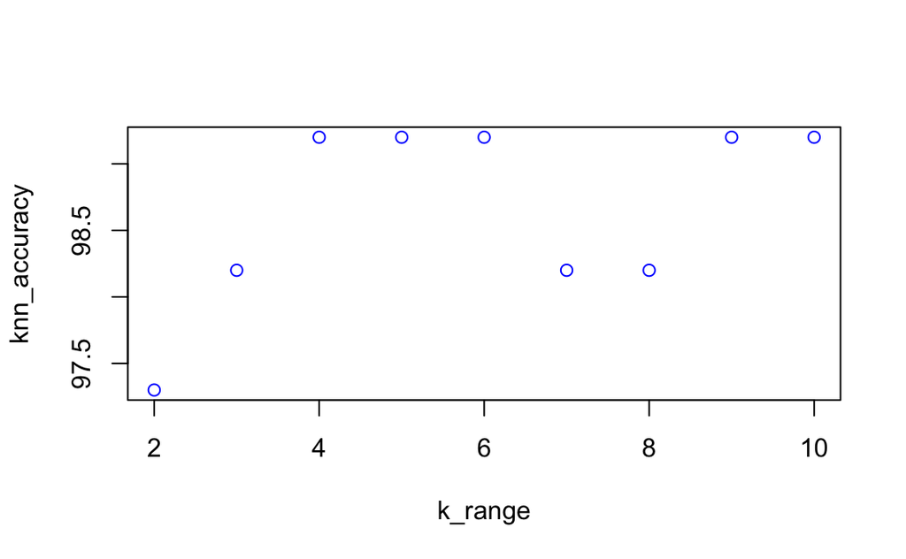

The chart shows the accuracy of the model based on the K values chosen between 2 and 10. As you can see, the model itself among all of these K values is fairly accurate(around 97-99% accuracy for k=2-10). However, if I were to apply this model and chose one K value for future knn predictions, I would chose a K of 10 because a good starting point for k is the square root of the training sample, and 10 is the closest of these values to that while being among the most accurate.

## 2 / Predicting Age of Abalones using Regression kNN

### 2.1 / Load csv and save target vector and training data

```r
df_abalone <- read.csv('https://s3.us-east-2.amazonaws.com/artificium.us/datasets/abalone.csv')

target_data <- as.vector(df_abalone$NumRings)
train_data <- df_abalone[-8]
```

### 2.2 / Encoding Categorical Variables

```r
#the only categorical variable is sex, which is a good case for using one-hot encoding. We will create two new columns (Male and Female) and do TRUE(1) or FALSE(0) for each column depending on Male of Female, or both columns will be FALSE(0) for Infant.

train_data$Male <- 0
train_data$Female <- 0
for (i in 1:nrow(train_data)){
  if (train_data$Sex[i] == 'I'){
    train_data$Male[i] <- FALSE
    train_data$Female[i] <- FALSE
  }
  if (train_data$Sex[i] == 'M'){
    train_data$Male[i] <- TRUE
    train_data$Female[i] <- FALSE
  }
  if (train_data$Sex[i] == 'F'){
    train_data$Male[i] <- FALSE
    train_data$Female[i] <- TRUE
  }
}

#get rid of the Sex column, now that sex is stored in two seperate columns.
train_data <- train_data[-8]
```

### 2.3 / Normalize all colums using min-max normalization

```r
#Remember not to normalize the two sex columns; train_data[8:9]
for (i in 1:(ncol(train_data)-2)){
  train_data[,i] <- (train_data[,i] - min(train_data[,i])) / (max(train_data[,i]) - min(train_data[,i]))
}
```

### 2.4 / Build knn.reg function

```r
knn_dist_list <- list()
new_data <- train_data[1,]
new_data_list <- list(0.44, 0.391,0.254, 0.2132, 0.0878, 0.21,0.5853, 0, 1)
for (i in 1:ncol(new_data)){
  new_data[1,i] <- new_data_list[i]
}

knn.reg <- function(new_data, target_data, train_data, k){
  # knndist <- sqrt((xnewdata - xtraindata)^2 + (ynewdata - ytraindata)^2 ...)
  for (i in 1:nrow(train_data)){
    knn_dist_presqrt <- 0
    knn_dist_unsqrt <- train_data[i,] - new_data[1,]
    for (q in 1:length(knn_dist_unsqrt)){
      knn_dist_presqrt <- knn_dist_presqrt + (knn_dist_unsqrt[,q])^2
    }
    knn_dist_final <- sqrt(knn_dist_presqrt)
    knn_dist_list <- append(as.numeric(knn_dist_list), knn_dist_final)

  }
  top_k_neighbors <- order(knn_dist_list, decreasing = TRUE)[1:3]
  #now find the ring values then multiply the weights and divide by the total of the weights (6)
  ring_k_neighbors <- ((3 * target_data[top_k_neighbors[1]]) +
    ((2) * target_data[top_k_neighbors[2]]) + (1* target_data[top_k_neighbors[3]]))/6
return(ring_k_neighbors)

}

knn.reg(new_data = new_data, target_data = target_data, train_data = train_data, k = 3)
```

```
[1] 11.83333
```

### 2.5 / use knn.reg function to predict rings from new data

```r
#call the knn.reg function using the correct variable/data
knn.reg(new_data = new_data, target_data = target_data, train_data = train_data, k = 3)
```

[output not shown]

```r
predicted_knn_reg <- list()
# generate random sample from train_data
sample <- sample.int(n = nrow(train_data), size = floor(.25*nrow(train_data)))
test_data <- train_data[sample,]
test_rings <- target_data[sample]
```

```r
#not evaluating because it took too long when knitting, so I saved to
#a .Rdata file instead before knitting
for (i in 1:nrow(test_data)){
  knn_val <- knn.reg(new_data = test_data[i,] , target_data = target_data, train_data = train_data)
  predicted_knn_reg <- append(as.numeric(predicted_knn_reg), knn_val)
}
```

```r
predicted_knn_reg <- load(file = predicted_knn_reg.Rdata)
```

[output not shown]

## 3 / Forecasting Future Sales Price

We obtained a data set containing 29580sales transactions for the years 2007 to 2019. The mean sales price for the entire time frame was 6.0973626^{5} (sd = 2.8170791^{5}).

Using a weighted moving average forecasting model that averages the prior 3 years (with weights of 4, 3, and 1), we predict next year’s average sales price to be around 6.379666^{5}.